# Markov chain Monte Carlo

Yuji Saikai ysaikai@unimelb.edu.au School of Mathematics and Statistics The University of Melbourne

# Introduction

In principle, the acceptance-rejection method could work in a high-dimensional problem

- if we found a PDF $g$ from which we can efficiently sample and
- $C$ for a tight envelope $Cg(x)$.

In 1-D cases, looking at the graph of target $f(x)$, we are often able to design a reasonable $Cg(x)$.

Even if an envelope is not very tight, we can wait for some time and obtain enough samples.

This is unlikely in high-dimensional problems because:

- hard to visualise PDF surfaces, and
- the rejection rate exponentially increases with dimensions.

Markov chain Monte Carlo (MCMC) is a general class of methods to sequentially generate samples from an **approximate distribution** that increasingly resembles a target distribution.

A sequence of samples are generated by simulating a Markov chain, which is designed to have the limiting distribution equal to the target distribution.

By being content with only approximate distributions, MCMC enables us to handle functions on high-dimensional spaces, which are common in modern complex problems.

> Since *Monte Carlo* simply refers to stochastic simulation, we might just call it *Markov chain simulation*. But, MCMC has sort of become the standard name everybody using statistical computing understands, perhaps because the acronym is just catchy.

# Markov chain

## Definition and notations

A Markov chain is a sequence of random variables $X_1,X_2\dots$ whose *futures are conditionally independent of the past given the present*. That is, for all $i\geq0$,
$$(X_{i+1}|X_i,X_{i-1},\dots) \sim (X_{i+1}|X_i) .$$

> In an IID sequence (e.g., Bernoulli process), futures are independent even of the present.

If each $X_i$ is a discrete random variable,
$$P(X_{i+1}=x_{i+1}|X_i=x_i,X_{i-1}=x_{i-1},\dots) = P(X_{i+1}=x_{i+1}|X_i=x_i).$$
In particular, if $x_{i+1}$ is an element of a finite set that is common for all $i\geq0$, then the Markove chain can be represented by the **transition matrix**, which we denote by $Q$. That is, for all $i\geq0$,
$$Q(j,k) = P(X_{i+1}=k|X_i=j) = P(X_1=k|X_0=j)$$
where $j,k$ are elements of the finite set, which is usually called **state space**. For instance, if we start with $X_0=j$, the probability of $X_2=k$ is
$$\begin{align}
P(X_2=k|X_0=j)
&= \sum_{s=1}^6 P(X_2=k,X_1=s|X_0=j)\\
&= \sum_{s=1}^6 P(X_2=k|X_1=s)\cdot P(X_1=s|X_0=j)\\
&= \sum_{s=1}^6 Q(j,s)\cdot Q(s,k)\\
&= Q^2(j,k)\\
\end{align}$$

As a concrete example, the following figure illustrates a Markov chain with state space of $\{1,2,3,4,5,6\}$.

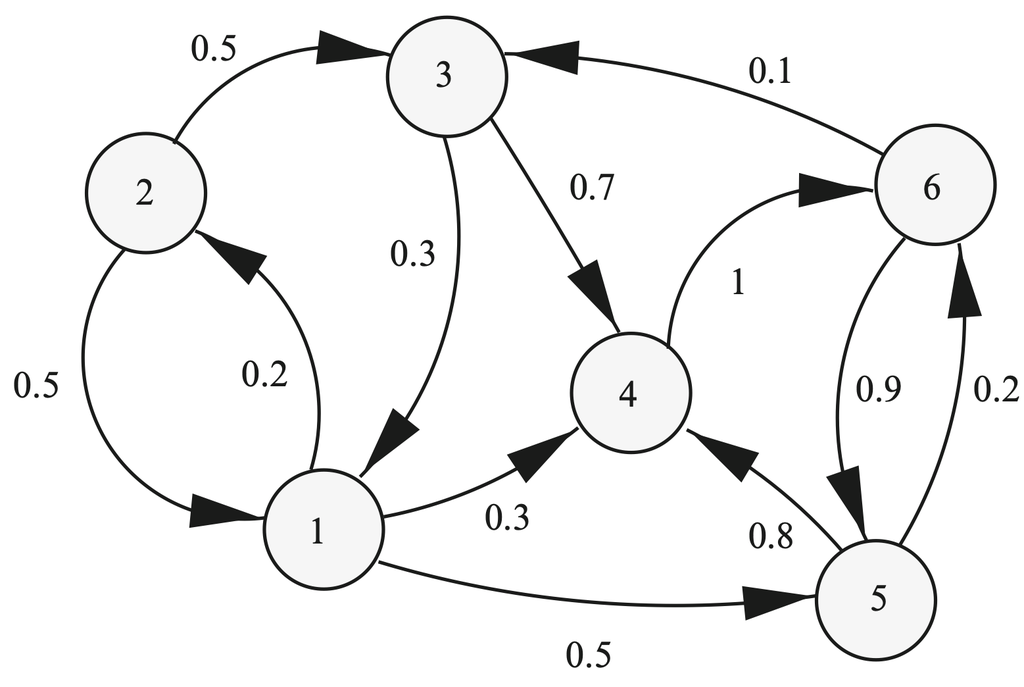

```r
Q
```

```
##      [,1] [,2] [,3] [,4] [,5] [,6]
## [1,]  0.0  0.2  0.0  0.3  0.5  0.0
## [2,]  0.5  0.0  0.5  0.0  0.0  0.0
## [3,]  0.3  0.0  0.0  0.7  0.0  0.0
## [4,]  0.0  0.0  0.0  0.0  0.0  1.0
## [5,]  0.0  0.0  0.0  0.8  0.0  0.2
## [6,]  0.0  0.0  0.1  0.0  0.9  0.0
```

For example, from $Q^2$, you can read off the probability of $X_2=5$ given $X_0=3$ as 0.15.

```r
Q%*%Q
```

```
##      [,1] [,2] [,3] [,4] [,5] [,6]
## [1,] 0.10 0.00 0.10 0.40 0.00 0.40
## [2,] 0.15 0.10 0.00 0.50 0.25 0.00
## [3,] 0.00 0.06 0.00 0.09 0.15 0.70
## [4,] 0.00 0.00 0.10 0.00 0.90 0.00
## [5,] 0.00 0.00 0.02 0.00 0.18 0.80
## [6,] 0.03 0.00 0.00 0.79 0.00 0.18
```

In general, the probability of $X_n=k$ given $X_0=j$ is $Q^n(j,k)$.

For most MCMC applications, we are interested in continuous random variables, i.e., the state space is uncountable. In this case, for $A\subset\mathbb{R}^d$,
$$P(X_{i+1}\in A|X_i=x_i,X_{i-1}=x_{i-1},\dots) = P(X_{i+1}\in A|X_i=x_i) .$$

In particular, we assume the conditional PDF $f_{X_{i+1}|X_i}(y|x)$ does not depend on $i$ and denote it by $q$. That is, for all $i\geq0$,
$$q(y|x) = f_{X_{i+1}|X_i}(y|x)=f_{X_1|X_0}(y|x),$$
where $x,y\in\mathbb{R}^d$ are states. We call $q$ the **transition density** of the (continuous-state) Markov chain.

A state distribution (i.e. marginal distribution) $f$ is said to be **stationary** if $f$ satisfies the following **global balance equations**:
$$f(x_{i+1}) = \int f(x_{i})q(x_{i+1}|x_{i})dx_{i}.$$

> It is a set of global balance equation**s**, as it holds for all pairs of $(x_i,x_{i+1})$.

To see how special the global balance is, recall that we always have
$$f_{i+1}(x_{i+1}) = \int f_{i}(x_{i})q(x_{i+1}|x_{i})dx_{i},$$
by marginalisation, i.e. integrating out $x_i$ from the joint PDF.

In general, two marginal PDFs $f_{i+1}$ and $f_{i}$ need not be the same.

However, if they happen to be identical under the transition $q$, then $f_{i+1} = f_{i} = f$ is a stationary distribution in the Markov chain characterised by $q$.

## Why Markov chain?

Given initial value/state $x_0$, using $q$, we can simulate a Markov chain, i.e. sequentially obtain samples $x_1,x_2,\dots,x_n$.

The rationale for Markov chain as a method for sampling from a desired target distribution $f$ is:

1. Under certain conditions, a Markov chain converges to a unique stationary distribution as $n\to\infty$.
2. We can **design** a Markov chain whose limiting distribution (hence, stationary distribution) has the target PDF $f$.
3. After running the Markov chain long enough $(i > I)$, we may expect the converging distribution to be almost stationary and samples $x_{I+1},x_{I+2},\dots,x_n$ with $n>>I$ to resemble IID samples from $f$.

> Samples from the first $I$ steps (so-called “burn-in” period) are often discarded.

It is easy to approximate the limiting distribution for a finite-state Markov chain.

For instance, for $Q$ defined above, the stationary distribution $p$ satisfies
$$pQ = p,$$
an eigenvector of $Q^T$ for eigenvalue of $1$.

```r
p <- Re(eigen(t(Q))$vectors[,1]) # eigenvector for eigenvalue = 1
p <- p/sum(p) # normalisation
p
```

```
## [1] 0.011978917 0.002395783 0.035936751 0.283660757 0.318639195 0.347388596
```

We can see $Q^{500}$ having the identical rows, each of which is almost equal to the stationary distribution.

```r
n <- 500
Qn <- Q%^%n
Qn
```

```
##            [,1]        [,2]       [,3]      [,4]      [,5]      [,6]
## [1,] 0.01197892 0.002395783 0.03593675 0.2836608 0.3186392 0.3473886
## [2,] 0.01197892 0.002395783 0.03593675 0.2836608 0.3186392 0.3473886
## [3,] 0.01197892 0.002395783 0.03593675 0.2836608 0.3186392 0.3473886
## [4,] 0.01197892 0.002395783 0.03593675 0.2836608 0.3186392 0.3473886
## [5,] 0.01197892 0.002395783 0.03593675 0.2836608 0.3186392 0.3473886
## [6,] 0.01197892 0.002395783 0.03593675 0.2836608 0.3186392 0.3473886
```

What does this imply? For example, suppose $X_0=4$ and $p_0 = (0,0,0,1,0,0)$. Then,

```r
p0 <- c(0,0,0,1,0,0)
p0%*%Qn
```

```
##            [,1]        [,2]       [,3]      [,4]      [,5]      [,6]
## [1,] 0.01197892 0.002395783 0.03593675 0.2836608 0.3186392 0.3473886
```

In general,

```r
p0 <- runif(6)
p0 <- p0/sum(p0) # random initial state distribution
p0%*%Qn
```

```
##            [,1]        [,2]       [,3]      [,4]      [,5]      [,6]
## [1,] 0.01197892 0.002395783 0.03593675 0.2836608 0.3186392 0.3473886
```

No matter which state we are in at the beginning, we will end up with the same state distribution at time 500 onwards.

In other words, an estimate of this limiting distribution using MCMC is

```r
n <- 1e6
x <- rep(0, n)
x[1] <- sample(1:6, 1) # random initial state
for (i in 2:n) {
  x[i] <- sample(1:6, 1, prob=Q[x[i-1],]) # MCMC sampling
}
table(x[501:n])/(n-500) # 500 burn-in periods
```

```
##
##           1           2           3           4           5           6
## 0.012244122 0.002446223 0.036106053 0.283478739 0.318473237 0.347251626
```

In contrast, if we sample from the true stationary distribution, an MC estimate is

```r
x <- sample(1:6, n-500, replace=T, prob=p)
table(x)/(n-500)
```

```
## x
##           1           2           3           4           5           6
## 0.012079040 0.002375188 0.035881941 0.283522761 0.317680840 0.348460230
```

## Design principles

The task in MCMC applications is to design a good Markov chain so that the chain converges to the desired target distribution. The following are key design principles.

**Ergodicity** is the condition for a Markov chain to converge to a unique stationary distribution irrespective of $x_0$. It consists of two intuitive properties: irreducibility and aperiodicity.

**Irreducibility** ensures that every state $x$ can be visited from every other state within finite steps $(i<\infty)$. This is important because, in MCMC, a sequence of samples are generated through dependent sampling according to the transition density $q$, and some $x_{i+1}$ may not be reached directly from current $x_i$, i.e., $q(x_{i+1}|x_i)=0$.

**Aperiodicity** prevents indefinite oscillation and allows the chain to converge to a stationary distribution.

Among the ergodic Markov chains, we could in principle choose a transition density $q$ that satisfies the global balance equations in order to ensure that the chain converges to our target $f$.

In practice, however, this is tricky and challenging because of the integral in the definition the global balance equations.

So, we typically impose stronger structure on $q$ called the **detailed balance equations**:
$$f(x)q(y|x) = f(y)q(x|y), \;\forall x,y.$$

> By integrating both sides over $x$ (or $y$), we see the detailed balance equations imply the global balance equations.